# 3 - Collaborator Engagement

2019-06-07

In collaborative research projects, there can be hundreds or even thousands of collaborators involved who gain pubmed-citable authorship on the publications arising from data collected. Since the first inception of the [collaborative research model](https://www.bmj.com/content/345/bmj.e5084) in 2010, there has arisen numerous research collaboratives which have run multiple projects with resultant publications. In addition to more traditional research metrics, a measure of the success of these projects is reflected in:

1. The number of new collaborators involved in each project (aka growth).
2. The involvement of collaborators across multiple projects (aka retention).
3. The total number of collaborators involved in the project (overall engagement e.g. growth + retention).

However, with potentially thousands of collaborators involved, being able to easily compare authors across multiple publications is a challenging task.

## **impact_auth()**

The `impact_auth()` function aims to simplify this process by providing an easy method to gain a comprehensive understanding of collaborator engagement using publication data.

Both the `extract_pmid()` and `extract_doi()` functions extract a list of authors that can be used directly by `impact_auth()`. The only mandatory requirements are a dataframe of the grouping variable (`pub_group` e.g. “project”) and the authors (“author”).

```r
data <- extract_pmid(pmid = c(25091299, 27321766, 30513129), get_auth = TRUE) %>%
  dplyr::mutate(project = factor(pmid,
                                 levels = c(25091299, 27321766, 30513129),
                                 labels =c("STARSurg-1", "DISCOVER", "OAKS-1"))) %>%
  dplyr::select(project, author)
```

| project | author |
| --- | --- |
| OAKS-1 | Nepogodiev D, Walker K, Glasbey JC, Drake TM, Borakati A, Kamarajah S, McLean K,… |
| DISCOVER | Drake TM, Nepogodiev D, Chapman SJ, Glasbey JC, Khatri C, Kong CY, Claireaux HA,… |
| STARSurg-1 | Chapman SJ, Glasbey J, Kelly M, Khatri C, Nepogodiev D, Fitzgerald JE, Bhangu A,… |

To track collaborator involvement over time, the author names must be matched between the groups (and dupliciates within groups excluded). Ideally authors would be matched on orcid (or similar unique identifier). Unfortunalely, that information is rarely stored in on-line repositories and so authors dervied in this way must be matched by last name and initials. However, `max_inital` allows flexiblity in how restrictive matching authors will be.

- If `max_inital` = 3, then the authors will be matched on their last name and exact initials (up to 3). This **more** restrictive matching will **overestimate** growth and **underestimate** retention (as the same person with a middle initial in one authorship list will be counted as two).
- If `max_inital` = 1, then the authors will be matched on their last name and first initial only. This **less** restrictive matching will **underestimate** growth and **overestimate** retention (as people with the same last name and first initial will be combined).

```r
example <- impact_auth(data, pub_group = "project", max_inital = 1, upset = TRUE, metric = TRUE)
```

## **Output**

### **1. $auth_out**

This will provide a basic summary of all unique collaborators across all groups (`author`), and their involvement in each (`pub_n`, `pub_group`).

| author | pub_n | pub_group |
| --- | --- | --- |
| kelly d | 1 | OAKS-1 |
| fox h | 1 | OAKS-1 |
| fowler a | 1 | OAKS-1 |
| gurung e | 1 | OAKS-1 |
| fawcett n | 1 | STARSurg-1 |
| hirani s | 1 | DISCOVER |
| vipond m | 1 | OAKS-1 |
| chung a | 1 | DISCOVER |
| dolbec k | 1 | DISCOVER |
| markham k | 1 | OAKS-1 |

This data can be used in a variety of ways, including a basic summary of involvement over time. For example, the number of projects authors/collaborators have been involved in:

```r
example$auth_out %>%
  finalfit::summary_factorlist(explanatory = "pub_n", column = TRUE) %>%
  tibble::as_tibble() %>% knitr::kable()
```

| label | levels | all |
| --- | --- | --- |
| pub_n | 1 | 2612 (89.5) |
|  | 2 | 271 (9.3) |
|  | 3 | 37 (1.3) |

### **2. $data_upset**

The `impact_auth()` function has the capability to derive information on how the authors relate using the `upset = TRUE` arguement (default).

| STARSurg-1 | DISCOVER | OAKS-1 |
| --- | --- | --- |
| 0 | 1 | 1 |
| 0 | 0 | 1 |
| 0 | 0 | 1 |
| 0 | 1 | 0 |
| 0 | 1 | 0 |
| 0 | 0 | 1 |
| 1 | 0 | 0 |
| 0 | 0 | 1 |
| 0 | 0 | 1 |
| 0 | 1 | 0 |

This data can be used in multiple ways, for example:

#### a). Descriptive summaries:

The `data_upset` output can be used by the ComplexHeatmap package to derive information on the relationships between authors and the groups (`pub_group` variable).

```r
upset_comb_mat <- ComplexHeatmap::make_comb_mat(example$data_upset)

knitr::kable(comb_name_size(upset_comb_mat))
```

| combination | n |
| --- | --- |
| STARSurg-1 | 306 |
| DISCOVER | 858 |
| STARSurg-1&DISCOVER | 74 |
| OAKS-1 | 1448 |
| STARSurg-1&OAKS-1 | 29 |
| DISCOVER&OAKS-1 | 168 |
| STARSurg-1&DISCOVER&OAKS-1 | 37 |

#### b). UpSet plots / Venn diagrams

UpSet plots provide an efficient way to visualize intersections of multiple sets compared to the traditional approaches (e.g. Venn Diagram). The `data_upset` output can be used directly to make UpSet plots by the ComplexHeatmap and UpSetR packages.

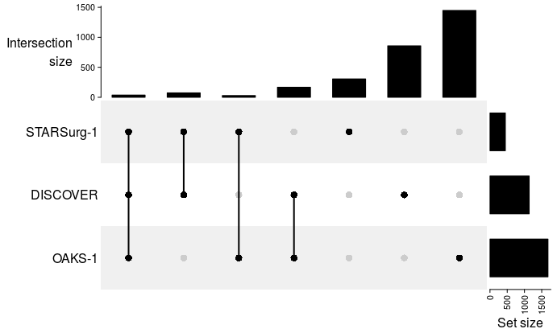

```r
example$data_upset %>%
  ComplexHeatmap::make_comb_mat() %>%
  ComplexHeatmap::UpSet(m = ., set_order = c("STARSurg-1", "DISCOVER", "OAKS-1"))
```

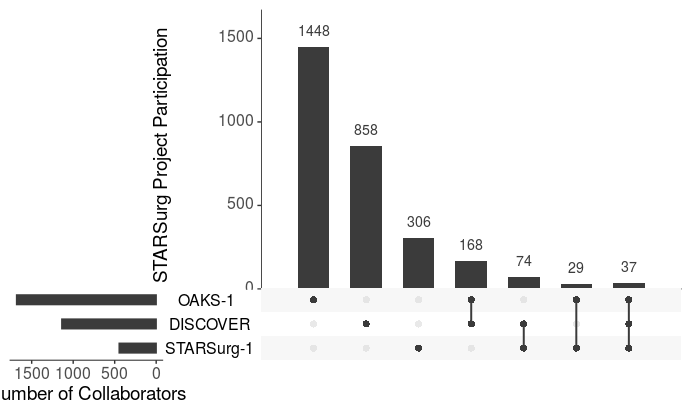

```r
example$data_upset %>%
  UpSetR::upset(data = ., keep.order = T, group.by = "degree",
                  sets = colnames(.), text.scale = 1.7,
                  mainbar.y.label = "STARSurg Project Participation",
                  sets.x.label = "Number of Collaborators")
```

#### c). Alluvial diagrams:

Alternatively, it can be used for Alluvial diagrams to provide a visualisation of author/collaborator involvement over time (variations of [Sankey diagrams](https://datavizcatalogue.com/methods/sankey_diagram.html)).

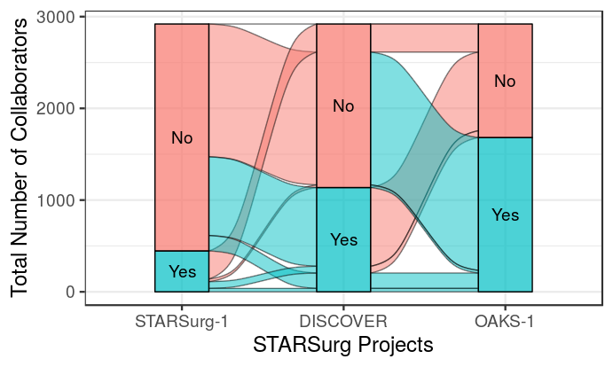

### **3. $metric**

Finally `impact_auth()` can provide metrics on author/collaborator engagement over time (note this requires `upset=TRUE`).

```r
knitr::kable(example$metric,"html") %>% kableExtra::scroll_box(width = "1000")
```

| level | n_total | n_total_prior | total_change_prop | n_old | n_new | n_new_prior | new_change_prop | n_retain | retain_prop |
| --- | --- | --- | --- | --- | --- | --- | --- | --- | --- |
| STARSurg-1 | 446 | NA | NA | 0 | 446 | NA | NA | 140 | 0.314 |
| DISCOVER | 1137 | 446 | 2.549 | 111 | 1026 | 446 | 2.300 | 205 | 0.180 |
| OAKS-1 | 1682 | 1137 | 1.479 | 234 | 1448 | 1026 | 1.411 | NA | NA |

a). `total_change_prop` and `new_change_prop` refers to the number of collaborators (in total or new) involved in each project compared to the previous project.

- A value of **1** indicates **consistant** engagement **compared with previous years** (stable growth).
- A value **>1** indicates an **increase** in engagement **compared with previous years** (accelerated growth).

b). `retain_prop` refers to the proportion of collaborators from each project involved in future projects (e.g. `n_retain` / `n_total`). This value can range from 0 (0%) to 1 (100%).